# WK11_2022_23

2025-09-09

```r
library(tidyverse)
library(readxl)
library(lubridate)
library(janitor)
library(purrr)
library(readr)
library(ggthemes)
library(ggeffects)
library(lme4)
```

```r
library(dplyr)
library(ggplot2)
library(emmeans)
library(broom.mixed)
library(viridis)
library(nlme)
library(mgcv)
setwd("C:/Users/Tobyz/Desktop/Toby在大学/Maloof Lab/S.tort-light-growth/Data")
```

*import plant data*

```r
plant_2223 <- read.csv("C:/Users/Tobyz/Desktop/Toby在大学/Maloof Lab/S.tort-light-growth/Data/UCD_2022_23_size_data_combined.csv") %>%
  clean_names() %>%
  mutate(survey_date = as.Date(survey_date, format = "%m/%d/%Y"))
summary(plant_2223)
```

```
##   survey_date            block                row            col
##  Min.   :2023-01-27   Length:13626       Min.   : 3.00   Length:13626
##  1st Qu.:2023-03-17   Class :character   1st Qu.:12.00   Class :character
##  Median :2023-04-20   Mode  :character   Median :22.00   Mode  :character
##  Mean   :2023-04-26                      Mean   :21.84
##  3rd Qu.:2023-06-12                      3rd Qu.:32.00
##  Max.   :2023-07-24                      Max.   :42.00
##
##      pop                  mf              rep              height
##  Length:13626       Min.   : 1.000   Min.   :  1.000   Min.   :  0.100
##  Class :character   1st Qu.: 2.000   1st Qu.:  4.000   1st Qu.:  2.300
##  Mode  :character   Median : 4.000   Median :  8.000   Median :  3.850
##                     Mean   : 4.363   Mean   :  8.753   Mean   :  9.836
##                     3rd Qu.: 6.000   3rd Qu.: 12.000   3rd Qu.:  7.700
##                     Max.   :12.000   Max.   :100.000   Max.   :130.000
##                     NA's   :2        NA's   :2         NA's   :10542
##   longest_leaf
##  Min.   : 0.000
##  1st Qu.: 2.100
##  Median : 3.200
##  Mean   : 3.827
##  3rd Qu.: 5.200
##  Max.   :12.700
##  NA's   :10551
```

*import light data*

```r
light_raw_2223 <- read_csv("C:/Users/Tobyz/Desktop/Toby在大学/Maloof Lab/S.tort-light-growth/Data/UCD_met_data.csv")%>%clean_names()%>%
 mutate(
    date = mdy(date),
    sol_rad_ly_day = as.numeric(sol_rad_ly_day),  # turn into number format
  )
```

```
## ──────────────────────────────────────────────────────── Delimiter: "," chr
## (17): Stn Name, CIMIS Region, Date, Jul, qc...9, qc...11, qc...13, qc...... dbl
## (15): Stn Id, ETo (in), Precip (in), Sol Rad (Ly/day), Avg Vap Pres (mBa... lgl
## (1): qc...7
```

*Investigate or filter out plants that show negative growth* #Q: How could we deal with bad observations? #Solution: find out tolerance value and then filter out observance data lager than the tolerance value #Figure A: Histogram showing the frequency of decreases in plant height between consecutive surveys. Most negative growth values are close to zero, likely reflecting measurement noise, while a small number of extreme decreases (<=–5 cm) suggest errors and were removed from subsequent analyses.

```r
#PID
pl_gr <- plant_2223 %>%
  unite("PID", pop:rep, sep = "_", remove = FALSE) %>%
  mutate(survey_date = as.Date(survey_date))

#find out plants with negative growth
pl_gr %>%
  arrange(PID, survey_date) %>%  # arrange in time sequence
  group_by(PID) %>%
  mutate(growth = height - lag(height)) %>%  # find out the diff btw nearby dates
  summarise(has_negative_growth = any(growth < 0, na.rm = TRUE)) %>%
  filter(has_negative_growth) -> neg_gr_pl
neg_gr_pl
```

```
## # A tibble: 453 × 2
##    PID     has_negative_growth
##    <chr>   <lgl>
##  1 BH_1_10 TRUE
##  2 BH_1_7  TRUE
##  3 BH_1_8  TRUE
##  4 BH_2_1  TRUE
##  5 BH_2_10 TRUE
##  6 BH_2_11 TRUE
##  7 BH_2_12 TRUE
##  8 BH_2_13 TRUE
##  9 BH_2_14 TRUE
## 10 BH_2_3  TRUE
## # ℹ 443 more rows
```

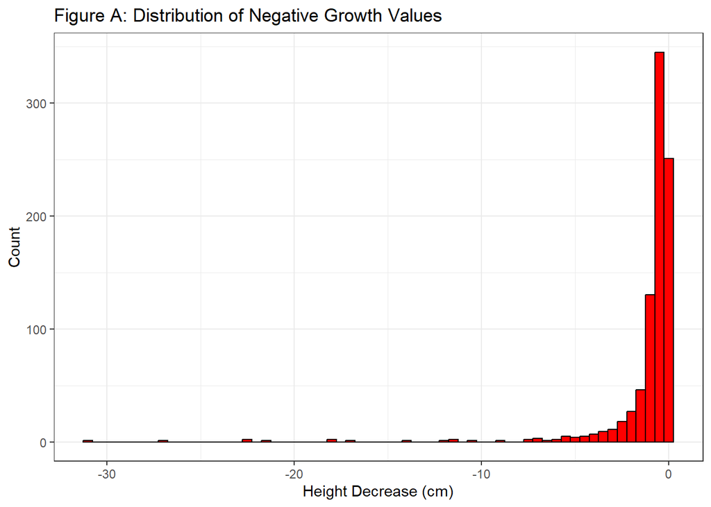

```r
#find out tolerance value
neg_gr_v <- pl_gr %>%
  arrange(PID, survey_date) %>%
  group_by(PID) %>%
  mutate(growth = height - lag(height)) %>%
  ungroup() %>%
  filter(growth < 0)

ggplot(neg_gr_v, aes(x = growth)) +
  geom_histogram(binwidth = 0.5, fill = "red", color = "black") +
  labs(
    title = "Figure A: Distribution of Negative Growth Values",
    x = "Height Decrease (cm)",
    y = "Count"
  ) +
  theme_bw()
```

```r
#filter out plants with negative growth < -5
pl_gr_cleaned <- pl_gr

repeat {
  pl_gr_cleaned <- pl_gr_cleaned %>%
    arrange(PID, survey_date) %>%
    group_by(PID) %>%
    mutate(growth = height - lag(height)) %>%
    filter(is.na(growth) | growth >= -5) %>%
    select(-growth) %>%
    ungroup()

  check <- pl_gr_cleaned %>%
    arrange(PID, survey_date) %>%
    group_by(PID) %>%
    mutate(growth = height - lag(height)) %>%
    filter(growth < -5)

  if (nrow(check) == 0) break
}
```

*Measure Growth via Daily Growth Rate*

```r
#define daily growth rate
pl_gr_daily <- pl_gr_cleaned %>%
  arrange(PID, survey_date) %>%
  group_by(PID) %>%
  mutate(
    prev_height = lag(height),
    prev_date = lag(survey_date),
    days_elapsed = as.numeric(survey_date - prev_date),
    daily_growth = (height - prev_height) / days_elapsed
  ) %>%
  ungroup()
```

*Calculate Daily Mean Solar Radiation*

```r
pl_lt <- pl_gr_daily %>%
  rowwise() %>%
  mutate(
    mean_light_ly_day = mean(
      light_raw_2223$sol_rad_ly_day[
        !is.na(light_raw_2223$date) &
        light_raw_2223$date > prev_date &
        light_raw_2223$date <= survey_date
      ],
      na.rm = TRUE
    ),
    n_days_light = sum(
      !is.na(light_raw_2223$date) &
      light_raw_2223$date > prev_date &
      light_raw_2223$date <= survey_date,
      na.rm = TRUE
    )
  ) %>%
  ungroup()
```

*Correlate Growth with Solar Radiation* #Q: How does plant growth correlate with solar radiation? #Test: Find correlation value and plot correlation #Figure B: Scatter plot showing the relationship between daily average solar radiation (ly/day) and daily growth rate (cm/day). Each point represents an observation, and the red line indicates the fitted linear regression.

```r
cor_result <- cor(
  pl_lt$daily_growth,
  pl_lt$mean_light_ly_day,
use = "complete.obs"
)

print(cor_result)
```

```
## [1] 0.3372124
```

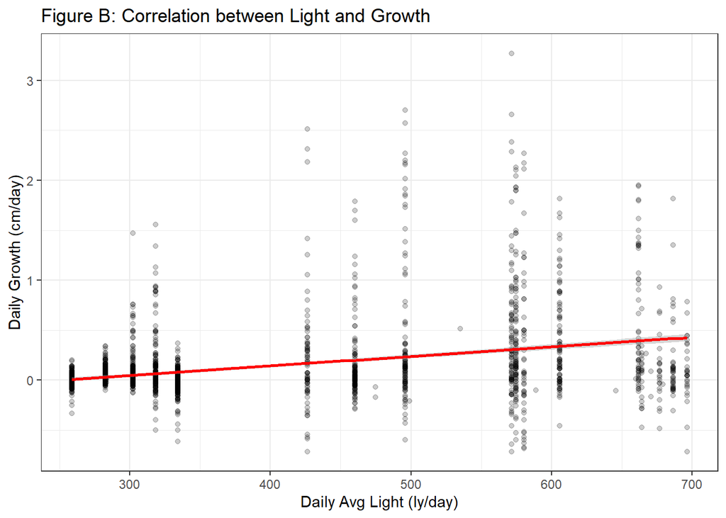

```r
#Plot correlation
ggplot(pl_lt, aes(x = mean_light_ly_day, y = daily_growth)) +
  geom_point(alpha = 0.2) +
  geom_smooth(method = "lm", color = "red") +
  labs(title = "Figure B: Correlation between Light and Growth", x = "Daily Avg Light (ly/day)", y = "Daily Growth (cm/day)") +
  theme_bw()
```

*Process data*

```r
#Standardization
pl_lt$mean_light_ly_day2 <- scale(pl_lt$mean_light_ly_day, center = TRUE, scale = TRUE)
mean_lt <- mean(pl_lt$mean_light_ly_day, na.rm = TRUE)
sd_lt   <- sd(pl_lt$mean_light_ly_day, na.rm = TRUE)

#Change Data type
pl_lt <- pl_lt %>%
  mutate(
    pop = factor(pop),
    PID        = factor(PID),
    block      = factor(block)
  )
```

*use mixed-effect model to fit relationship between plant growth and light radiation with population as random effect* #Q: Does daily solar radiation positively affect daily growth rate across all populations? #Test: Fit a mixed-effect model with population as a random slope.

```r
pl_lt.lmer <- lmer(
  daily_growth ~ mean_light_ly_day2 +
    (1 + mean_light_ly_day2 | pop),
  data = pl_lt, REML = TRUE
)
summary(pl_lt.lmer)
```

```
## Linear mixed model fit by REML ['lmerMod']
## Formula: daily_growth ~ mean_light_ly_day2 + (1 + mean_light_ly_day2 |
##     pop)
##    Data: pl_lt
##
## REML criterion at convergence: 1656
##
## Scaled residuals:
##     Min      1Q  Median      3Q     Max
## -4.1389 -0.2891 -0.0481  0.1374  8.6048
##
## Random effects:
##  Groups   Name               Variance Std.Dev. Corr
##  pop      (Intercept)        0.02193  0.14807
##           mean_light_ly_day2 0.00437  0.06611  0.97
##  Residual                    0.11366  0.33713
## Number of obs: 2415, groups:  pop, 23
##
## Fixed effects:
##                    Estimate Std. Error t value
## (Intercept)         0.13632    0.03902   3.494
## mean_light_ly_day2  0.07966    0.01999   3.986
##
## Correlation of Fixed Effects:
##             (Intr)
## mn_lght_l_2 0.916
```

*overall effect of solar radiation on plant daily growth* #Figure C: Relationship between daily average solar radiation and predicted daily growth rate (cm/day), aggregated across all populations. Each hexagon represents the density of observations. The black line shows the fitted regression slope .

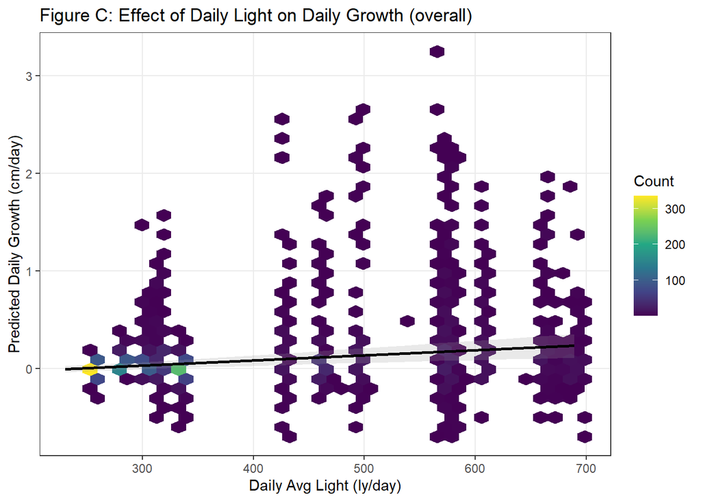

```r
#Unscaling
pred_all <- ggpredict(pl_lt.lmer, terms = "mean_light_ly_day2") %>%
  as.data.frame() %>%
  mutate(light_orig = x * sd_lt + mean_lt)

#Plot
p_overall <- ggplot() +
  geom_hex(data = pl_lt,
           aes(x = mean_light_ly_day, y = daily_growth), bins = 35) +
  scale_fill_viridis_c(name = "Count") +
  geom_ribbon(data = pred_all,
              aes(x = light_orig, ymin = conf.low, ymax = conf.high),
              alpha = .22, fill = "grey60") +
  geom_line(data = pred_all,
            aes(x = light_orig, y = predicted), linewidth = 1) +
  labs(title = "Figure C: Effect of Daily Light on Daily Growth (overall)",
       x = "Daily Avg Light (ly/day)",
       y = "Predicted Daily Growth (cm/day)") +
  theme_bw() +
  theme(panel.grid.minor = element_blank())
p_overall
```

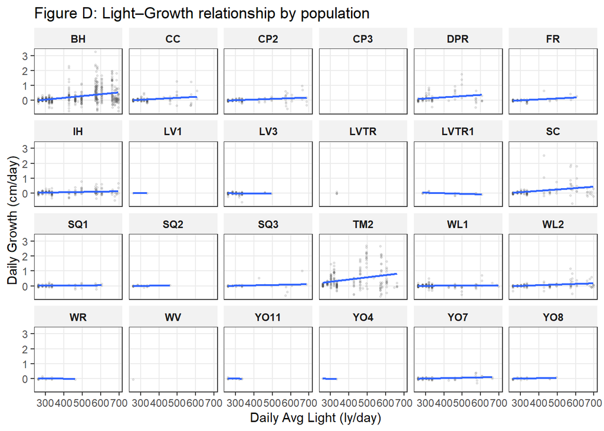

```r
p_facet <- ggplot(pl_lt,
                  aes(mean_light_ly_day, daily_growth)) +
  facet_wrap(~ pop, ncol = 6) +
  geom_point(alpha = .15, size = .6, color = "grey35") +
  geom_smooth(method = "lm", se = FALSE, linewidth = .8) +
  labs(title = "Figure D: Light–Growth relationship by population",
       x = "Daily Avg Light (ly/day)",
       y = "Daily Growth (cm/day)") +
  theme_bw() +
  theme(strip.background = element_rect(fill = "grey95", color = NA),
        strip.text = element_text(face = "bold"),
        panel.grid.minor = element_blank())
p_facet
```

*Find slope of plant growth and solar radiation for each population* #Q: Which populations show significantly positive or negligible slopes in the light–growth relationship? #Method: Extract slopes and 95% confidence intervals for each population from the mixed-effects model #Figure E. Population-specific slopes with 95% confidence intervals. #The slope of the light–growth relationship (cm/day per Ly/day) is shown for each population. Points indicate estimated slopes and horizontal lines show 95% CIs. The vertical dashed line marks zero effect. Most populations exhibit positive slopes, suggesting that higher solar radiation is generally associated with faster daily growth, although the strength and significance of this relationship vary across populations.

```r
#slope and standard deviation of fixed effects
b_fix  <- fixef(pl_lt.lmer)["mean_light_ly_day2"]
V_fix  <- vcov(pl_lt.lmer)["mean_light_ly_day2","mean_light_ly_day2"]

#slope and standard deviation of random effects
re <- ranef(pl_lt.lmer, condVar = TRUE)
re_pop <- re$pop
postVar <- attr(re$pop, "postVar")
sl_col <- which(colnames(re_pop) == "mean_light_ly_day2")

#create the tibble of slopes for each population
pop_slope <- tibble(
  parent_pop   = rownames(re_pop),
  rand_slope   = re_pop[ , "mean_light_ly_day2"],
  rand_var     = sapply(seq_len(dim(postVar)[3]), function(i) postVar[sl_col, sl_col, i])
) %>%
  mutate(
    slope_SD   = b_fix + rand_slope,
    se_SD      = sqrt(V_fix + rand_var),
    lower_SD   = slope_SD - 1.96*se_SD,
    upper_SD   = slope_SD + 1.96*se_SD
  )

pop_slope <- pop_slope %>%
  mutate(
    slope_per_Wm2 = slope_SD / sd_lt,
    lower_per_Wm2 = lower_SD / sd_lt,
    upper_per_Wm2 = upper_SD / sd_lt
  )%>%
  select(parent_pop, slope_per_Wm2, lower_per_Wm2, upper_per_Wm2)
pop_slope
```

```
## # A tibble: 23 × 4
##    parent_pop slope_per_Wm2 lower_per_Wm2 upper_per_Wm2
##    <chr>              <dbl>         <dbl>         <dbl>
##  1 BH              0.00113      0.000837       0.00142
##  2 CC              0.000595     0.000124       0.00106
##  3 CP2             0.000425     0.0000137      0.000835
##  4 DPR             0.000889     0.000429       0.00135
##  5 FR              0.000462    -0.0000947      0.00102
##  6 IH              0.000307    -0.0000424      0.000656
##  7 LV1             0.000503    -0.000362       0.00137
##  8 LV3             0.000251    -0.000328       0.000830
##  9 LVTR            0.000481    -0.000347       0.00131
## 10 LVTR1           0.000208    -0.000393       0.000808
## # ℹ 13 more rows
```

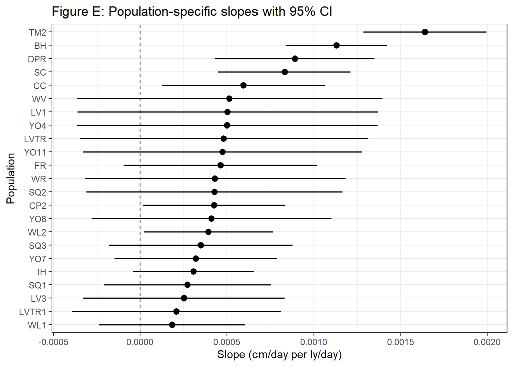

```r
write.csv(pop_slope, "population_slopes.csv", row.names = FALSE)

#plot
ggplot(pop_slope, aes(x = reorder(parent_pop, slope_per_Wm2), y = slope_per_Wm2)) +
  geom_hline(yintercept = 0, linetype = 2) +
  geom_pointrange(aes(ymin = lower_per_Wm2, ymax = upper_per_Wm2), linewidth = .6) +
  coord_flip() +
  labs(title = "Figure E: Population-specific slopes with 95% CI",
       x = "Population", y = "Slope (cm/day per ly/day)") +
  theme_bw()
```